# A Twitter Social Network Analysis of Colmex Economist

Diego López Tamayo [^1]

Emilio Nazará Sosa [^2]

- Repositorio [disponible en GitHub](https://github.com/diego-eco/red_tuitera_Colmex).
- Versión en slides [disponible aquí.](https://diego-eco.github.io/files/pres_redes_colmex.pdf)

# Motivación

Twitter es una plataforma a través de la cual los académicos pueden comunicarse con audiencias más amplias. A menudo, se ha acusado a los economistas de adoptar actitudes de superioridad y ser distantes con el público en general (Fourcade et al., 2015). Esta idea se ha atribuido a la baja difusión de la ciencia económica con el público y la falta de diversidad de la profesión (Della Giusta et al., 2018).

Las investigadoras Marina Della Giusta, Danica Vukadinovic-Greetham y Sylvia Jaworska de la Universidad de Reading, Inglaterra, encuentran diferencias en la forma en que los investigadores se comunican con audiencias no académicas. Recopilan los datos de miles de tweets de las cuentas de los mejores 25 economistas y 25 científicos identificados por IDEAS y Science.

Los resultados indican que los economistas tuitean menos, mencionan a menos personas y tienen menos interacciones con extraños. Además, utilizan un lenguaje menos accesible y un tono más distante que un grupo comparable de científicos.

# Pregunta de investigación y objetivos

Con la motivación del artículo de (Della Giusta et al., 2018), este análisis busca explotar los datos de Twitter con la finalidad de observar si existe un fenómeno similar en la comunidad tuitera del Colegio de México (Colmex). Con el fin de responder ¿cómo se relacionan en Twitter los economistas del Centro de Estudios Económicos (CEE) comparados con sus equivalentes de otros centros del Colegio?

Se considera al personal administrativo y de la biblioteca, así como a los otros 7 centros de estudio que conforman al Colegio de México: CEAA, CEDUA, CEE, CEH, CEI, CELL, CES.

El objetivo de la investigación es identificar la red tuitera del Colmex y sus comunidades principales. La estructura de la red será analizada para obtener la información principal de su composición, así como la interacción entre personas del mismo centro de estudios y también con los individuos externos a ellos.

Con la información que se obtenga de la red, como objetivo secundario, se identificará la relación que tiene cada centro con los agentes externos. Para esto es necesario generar las estadísticas descriptivas sobre las cuentas externas seguidas por centro. Los análisis obtenidos permitirán observar la relación de los agentes principales con los agentes externos de la red, así cómo posibles diferencias entre los centros de estudios. Con esto es posible conocer de mejor forma el comportamiento de los economistas en el Colmex con agentes externos a la comunidad y si tiene alguna relación con los resultados obtenidos en los estudios previos sobre el tema.

# Datos

Los datos se recopilaron por medio de una [encuesta electrónica en Google Forms](https://docs.google.com/forms/d/e/1FAIpQLSc-IxQDgLAiIE6_u2uE1rc72hFy4f30zEZbYxa4vv75VPuaJQ/viewform) distribuida a los miembros de la comunidad Colmex y complementados con una búsqueda individual de los miembros de cada centro en caso de que no respondieran la encuesta y si tuvieran una cuenta de Twitter. Las preguntas de la encuesta se encuentran disponibles en el Anexo 1. Los campos de la base de datos consistían de las 4 variables: Twitter ID, Username, Centro de estudios, Actualmente en Colmex.

Se registraron 310 usuarios Colmex, a estas cuentas se les pasó por un filtro adicional, eliminando aquellas cuentas privadas o con restricciones, teniendo al final 299 usuarios con información disponible para el estudio.

Con la interfaz [Twitter API](https://developer.twitter.com/en) en Python se obtuvo la información de las interacciones de seguimiento (followings) de los agentes y con estas conexiones se realizaron las red dirigida y no dirigida del Colmex, en donde los nodos corresponden a los Twitter ID de cada agente y las aristas o conexiones están formadas por los followings. En la red dirigida una arista AB entre el agente A y B se forma si el agente A sigue al B, y de igual manera se formará la arista BA si el agente B sigue al A; para la red no dirigida es indispensable que ambos individuos tengan una relación de following-follower, es decir, que existan los ejes AB y BA. Esto se ilustra en la Figura

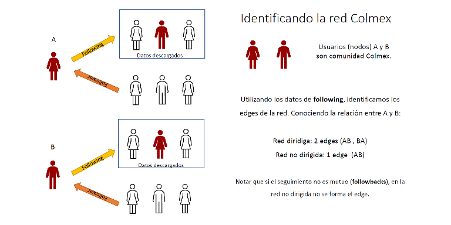

Identificando la red Colmex

Se obtuvieron 276,364 registros de los followings de las cuentas con información disponible.

Con las herramientas de las paqueterías graph-tool y networkx se construyeron las redes, así como la obtención de las estadísticas descriptivas y la visualización de estas gráficas; con el dibujo de las redes y los datos que se tienen es posible realizar una exploración de la gráfica e identificar los nodos de mayor centralidad, así como la relación con agentes externos a la comunidad Colmex.

La gráfica construida de la red dirigida consiste de 299 nodos o usuarios y 11,184 aristas dirigidas, mientras que la red no dirigida descarta 53 nodos que no tienen ninguna conexión de follow-back, dejando 246 nodos y 2,951 aristas que los conectan.

# Análisis exploratorio

La Figura muestra la distribución de los usuarios de Twitter en el Colmex por centro de estudios al que pertenecen y por el estado de su relación con el Colegio, si son miembros actuales o lo fueron en alguna ocasión.

La mayoría de los respondentes forman parte de los centros de estudio Económico (26.1%) e Internacional (36.5%), en esta muestra el interés es del Centro de Estudios Económicos (CEE), por lo cuál que se tenga aproximadamente un cuarto de la muestra perteneciente a este centro nos permitirá tener mejores resultados a si se tuviera una proporción menos significativa, ya que es posible que por su tamaño también se tengan menos interacciones.

Por otro lado, se tiene un equilibrio entre los miembros actuales y los que formaron parte alguna vez, en este aspecto es importante eso para que se tenga diversidad entre las opiniones internas y externas en la red.

Separando de manera interna y externa las cuentas que los usuarios de la comunidad Colmex siguen, se construye la Figura Figura , la cuál indica el porcentaje de following de las 20 cuentas más seguidas por la muestra. Se observan las 20 cuentas pertenecientes a la comunidad que son seguidas, la primera de ellas sin mucha sorpresa es la misma cuenta del Colegio de México (@elcolmex), la cuál es seguida por poco más del 80% de los nodos analizados. Concerniente al estudio, la segunda cuenta más seguida corresponde al Doctor Gerardo Esquivel (@esquivelgerardo), profesor del CEE y con un seguimiento de poco menos del 80% de los nodos, con una brecha de casi 20% respecto a la tercera posición de la tabla, el político mexicano y exestudiante del CEI, Marcelo Ebrard (@m_ebrard).

Cabe destacar que 5 de las 20 cuentas internas con más seguidores de la comunidad Colmex son del CEE. (esquivelgerardo, rmcamposvazquez, MGF91, EvaOArceo, ArturoHerrera_G). Mientras que el otro sector importante corresponde al CEI, donde aparecen 9 cuentas de las 20 más seguidas; estos resultados se pueden deber al tamaño de cada centro en la muestra.

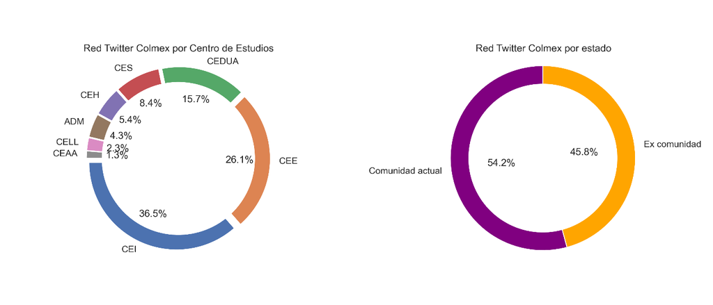

Distribución de la red Colmex por centro de estudios y status

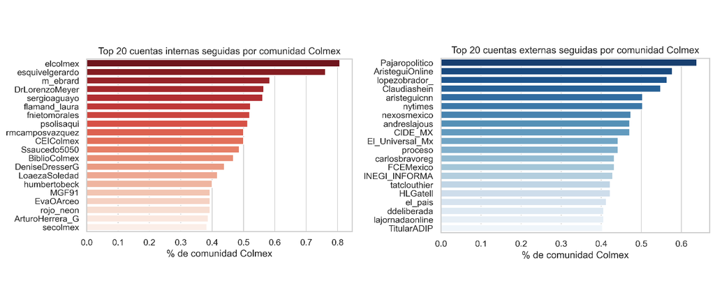

Top 20 cuentas internas y externas seguidas por comunidad Colmex

Analizando por otro lado las cuentas externas a la comunidad Colmex, la primera de ellas, seguida por poco más del 60% de la comunidad es la cuenta de Animal Político (@pajaropolitico), una página digital de noticias relacionadas a la ciudadanía, con temas de corrupción, desigualdad, discriminación, entre otras. Lo que se puede observar en las cuentas externas, es una clara tendencia a ser páginas de noticias principalmente, y también incluyendo cuentas de políticos, como la del actual presidente Andrés Manuel López Obrador (@lopezobrador).

Hay que resaltar que la mayoría de las cuentas externas que se encuentran en el top 20 tienen un seguimiento de aproximadamente el 40% de los miembros de la comunidad Colmex, con un máximo de 60% para la cuenta más seguida; mientras que en las cuentas internas el promedio está alrededor del 50% y un máximo de 80%, teniendo una tendencia a seguir más a las cuentas pertenecientes a la propia comunidad que a aquellas de una institución o persona ajena.

# Resultados

La Figura muestran la distribución de grado o degree distribution de las redes dirigida y no dirigida respectivamente. Las dos distribuciones parecen seguir una Power Law Distribution, en donde la frecuencia decrece exponencialmente con el grado de los nodos, muchos nodos tienen pocas conexiones mientras que conforme se aumenta las interacciones también va disminuyendo la cantidad de nodos que las poseen.

Observemos en la Tabla 1 que el Assortativity coefficient o Asortatividad es la preferencia de los nodos por agruparse a otros nodos que poseen cualidades similares a ellos, en esto caso se analizan las cualidades de pertenecer a un Centro de Estudios en específico o de tener un estatus en particular, ser miembros actuales o haber pertenecido en un pasado.

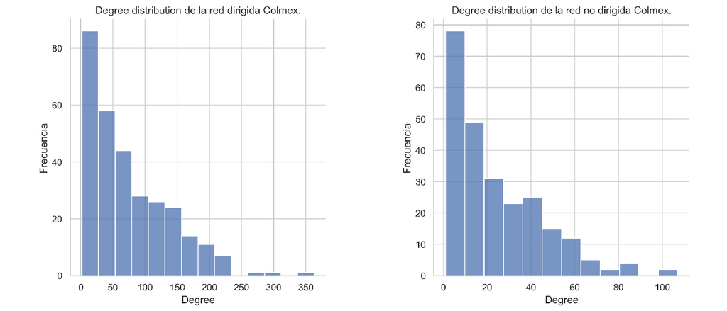

Degree distribution de red Colmex dirigida y no dirigida

Los bajos niveles de asortatividad por estatus indican que no hay una preferencia de los nodos por relacionarse con personas que en esos momentos sean miembros o que lo hayan sido, si bien es positivo este valor si hay un poco de sesgo, pero no es significativo, posiblemente se deba más a las promociones de estudiantes que se conectan en el lapso que cursan en el Colegio.

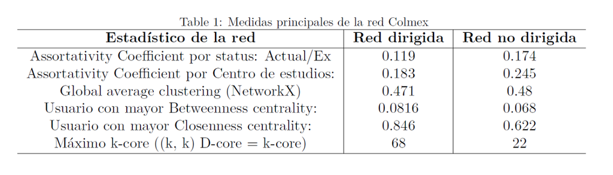

La asortatividad por centro es un poco mayor, pero sin llegar a niveles significativos, lo que cabe destacar es que, en la red no dirigida, donde es necesario que los 2 nodos se sigan mutuamente, la asortatividad es mayor, indicando una ligera tendencia a relacionarse con personas del mismo centro, esto es consistente con el hecho de que los estudiantes y profesores conviven más dentro de estos grupos, pero sin llegar a tener una segregación a los demás centros.

El Global Average Clustering o Coeficiente de agrupamiento indica que tanta interconexión existe entre los nodos de la red, teniendo un valor cercano a $1/2$ se puede decir que esta es una red bastante interconectada donde la mitad de sus componentes están agrupados con sus vecinos.

La Betweenness Centrality o Intermediación es la medida de centralidad en una red que está relacionada con el número de caminos más cortos entre los nodos que pasan por un nodo en particular, el máximo valor en esta red de la intermediación es menos del 10%, por lo que se puede decir que las interacciones de los nodos permiten una diversificación de la información, permitiendo varios caminos para transmitirla.

Por otro lado, la Closeness Centrality o grado de proximidad es la medida de cercanía de los nodos en relación con los demás nodos de la red, permite detectar aquellos nodos que facilitan la transmisión de información en la red. En este caso se tiene un alto grado de proximidad, por lo cuál indica que los nodos tienen una alta cercanía entre ellos, de esta manera se puede transmitir con gran facilidad la información entre toda la red a partir de ciertos nodos.

El máximo K-core de las redes es 68 para la red dirigida y 22 para la no dirigida, hay que tener en cuenta el tamaño de las redes, la no dirigida es mucho menor debido a la cantidad de conexiones que se eliminan debido a que no son bilaterales. Analizando la red dirigida, la subgráfica más grande que se puede hacer donde al menos se tengan ciertas conexiones es cuando se consideran todos los nodos con al menos 68 conexiones entre ellos, indicando así que la red del Colegio no es una red tan dispersa.

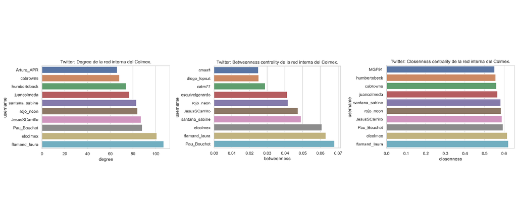

Analizando la distribución de edges y las principales medidas de centralidad en la Figura , observamos que @flamand_laura, profesora del CEI, se encuentra en los principales lugares. Notablemente es la única profesora en los primeros lugares seguida de alumnos y ex alumnos del CEI y del CEE. @esquivelgerardo, @humbertobeck y @calm77 son los otros profesores que aparecen más abajo en los rankings.

La composición de los nodos mejor conectados en la red Colmex refleja la mayor actividad en Twitter que tienen los alumnos y ex alumnos respecto a los profesores, esto puede explicarse con un argumento de brecha generacional en el uso de redes sociales. Este argumento se refuerza al ver la baja representación de los centros que únicamente cuentan con posgrados (CEAA, CELL).

El nivel máximo de closenness centrality es de 0.6 y no es significativamente menor para el resto del top 10, dado que es una forma de detectar nodos que pueden difundir información de manera muy eficiente a través de una red podemos decir que es una red bien comunicada donde sus nodos principales pueden transmitir información y ninguno posee demasiada influencia en el flujo (máximo betweenness centrality es de 0.067).

# Visualización de la red interna no dirigida

Presentamos a continuación en las Figuras y la red no dirigida (sólo followbacks) de la comunidad interna mediante el algoritmo *ARF spring block layout*. Se prioriza la visualización y análisis de la red no dirigida en el resto del documento, esto se debe a la mejor visualización (3 mil edges vs 11 mil de la dirigida) y mejor desempeño en medidas de asortatividad (Ver Tabla )

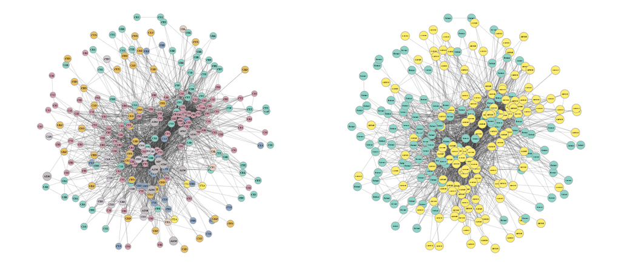

Red interna Colmex por centro de estudios y status

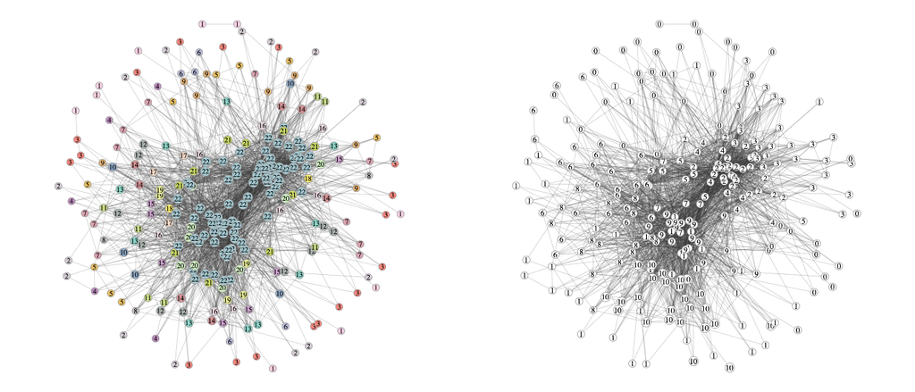

Red interna Colmex. K-core decomposition y comunidades por minimize block model

# Análisis de comunidades

La Figura nos muestra las 11 las comunidades detectables por el método *minimize block model*. No se detecta un patrón observable en las comunidades que detecta el algorítmo (no separa en centros de estidio o status). Para atender esto, la Tabla 2 muestra el centro con mayor porcentaje en cada bloque, lo que permite identificar ciertos patrones.

Al quedarnos con el grupo más relevante en cada bloque se observa que el CEI y CEE predominan en casi todas las comunidades, destaca el bloque 1 y 10 que tienen mayoría de usuarios del CES y CEDUA respectivamente. Estos resultados se pueden explicar, en parte, por la mayoría absoluta que tienen el CEI y CEE en los datos recolectados. El bloque 2 también destaca porque es el único compuesto al 100% por usuarios de un sólo centro balanceado entre actuales y ex comunidad.

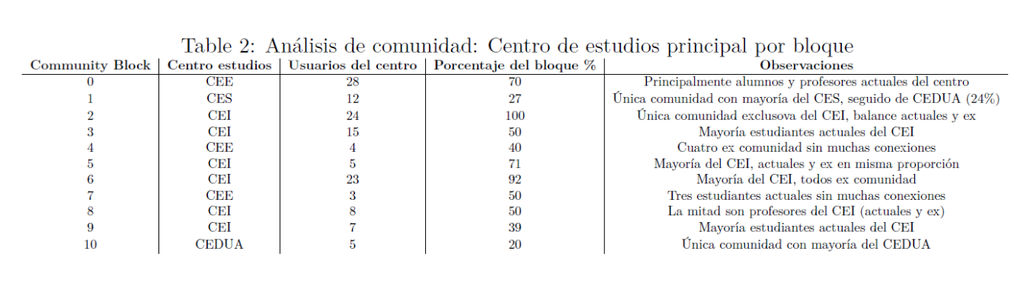

# Interacción con la red externa

Notemos en la Tabla 3 que al normalizar el número de cuentas seguidas por el número de usuarios en cada centro de estudios obtenemos el Following rate: CES y CEH son los centros que siguen en promedio a más cuentas externas al Colmex.

Cuando quitamos las cuentas repetidas (si dos usuarios del mismo centro siguen a una cuenta, se toma una en cuenta una sola vez) y normalizamos obtenemos el Following diversity rate: De nuevo el CES y CEH son los centros que siguen más cuentas únicas externas al Colmex.

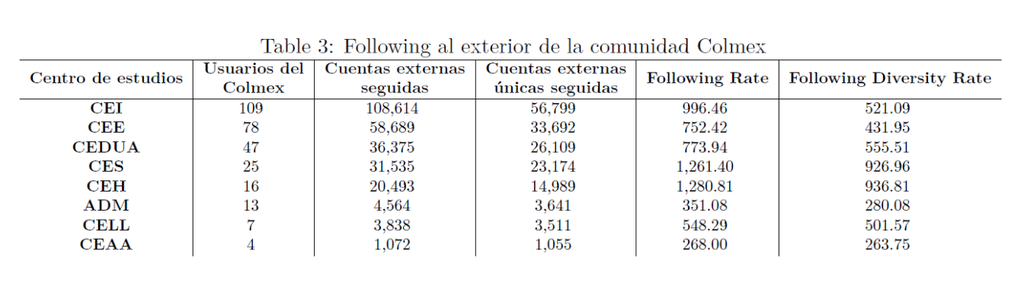

El CEE queda en 6to lugar en este índice, indicando que los economistas del Colmex tienden en promedio a seguir menos cuentas externas que sus pares de otros centros de estudios, superando únicamente a la Biblioteca/Administracíón y el CEAA que es el centro con menos tuiteros.

# Conclusiones

La red del Colmex en general está bien diversificada, no tiene nodos que tengan el control de la red y la información puede ser transmitida por diversos mecanismos. Internamente es una red bien comunicada, mientras que de manera externa si hay diferencias en cuanto a cada centro de estudios.

Los miembros del CEE tienden a seguir menos cuentas externas a la comunidad que los demás centros de estudios respaldando, en parte, los resultados de (Della Giusta et al., 2018).

Dentro de las limitaciones, puede ser que la muestra recopilada no sea representativa de toda la comunidad tuitera Colmex, se requiere una encuesta más exhaustiva. El estudio puede complementarse con análisis del lenguaje en los Tweets y sería una línea de investigación a futuro.

# Referencias

- Della Giusta, M., Vukadinovic-Greetham, D., & Jaworska, S. (2018). Tweeting Economists: Antisocial in the socials? In MPRA Paper (No. 89527). University Library of Munich, Germany.
- Fourcade, M., Ollion, E., & Algan, Y. (2015). La superioridad de los economistas. Revista de Economía Institucional, 17 (33), 13–43. https://doi.org/10.18601/01245996.v17n33.02
[^1]: El Colegio de México, diego.lopez@colmex.mx
[^2]: El Colegio de México, enazara@colmex.mx